# Análisis de datos bayesiano

Para esta sección seguiremos el libro [Doing Bayesian Data Analysis](https://sites.google.com/site/doingbayesiandataanalysis/) de Kruschke.

Hasta ahora hemos estudiado métodos estadísticos frecuentistas (o clásicos), el punto de vista frecuentista se basa en los siguientes puntos (Wasserman, 2005):

1. La probabilidad se refiere a un límite de frecuencias relativas, las probabilidades son propiedades objetivas en el mundo real.
2. En un modelo, los parámetros son constantes fijas (desconocidas). Como consecuencia de que los parámetros son constantes no se pueden realizar afirmaciones probabilísticas útiles en relación a éstos.
3. Los procedimientos estadísticos deben diseñarse con el objetivo de tener propiedades frecuentistas bien definidas. Por ejemplo, un intervalo de confianza del 95% debe contener el verdadero valor del parámetro con frecuencia límite de al menos el 95%.

Por su parte, el paradigma Bayesiano se basa en los siguientes postulados:

1. La probabilidad describe grados de creencia, no frecuencias limite. Como tal uno puede hacer afirmaciones probabilísticas acerca de muchas cosas y no solo datos sujetos a variabilidad aleatoria. Por ejemplo, puedo decir: “La probabilidad de que Einstein tomara una copa de te el 1ro de agosto de 1948” es 0.35, esto no hace referencia a ninguna frecuencia relativa sino que refleja la certeza que yo tengo de que la proposición sea verdadera.
2. Podemos hacer afirmaciones probabilísticas de parámetros.
3. Podemos hacer inferencia de un parámetro $\theta$ por medio de distribuciones de probabilidad. Las infernecias como estimaciones puntuales y estimaciones de intervalos se pueden extraer de dicha distribución.

Kruschke describe los puntos de arriba como dos ideas fundamentales del análisis bayesiano:

- La inferencia bayesiana es la reubicación de creencias a lo largo de posbilidades. *How often have I said to you that when you have eliminated the impossible, whatever remains, however improbable, must be the truth?* (Doyle, 1890, chap. 6).
- Las posibilidades son valores de los parámetros en modelos descriptivos.

### Probabilidad subjetiva

¿Qué tanta certeza tienes de que una moneda acuñada por la casa de moneda mexicana es justa? Si, en cambio, consideramos una moneda antigua y asimétrica, ¿creemos que es justa? En estos escenarios no estamos considerando la verdadera probabilidad, inherente a la moneda, lo que queremos medir es el grado en que creemos que cada probabilidad puede ocurrir.

Para especificar nuestras creencias debemos medir que tan verosímil pensamos que es cada posible resultado. Describir con presición nuestras creencias puede ser una tarea difícil, por lo que exploraremos como *calibrar* las creencias subjetivas.

#### Calibración

Considera una pregunta sencilla que puede afectar a un viajero: ¿Qué tanto crees que habrá una tormenta que ocasionará el cierre de la autopista México-Acapulco en el puente del 20 de noviembre? Como respuesta debes dar un número entre 0 y 1 que refleje tus creencias. Una manera de seleccionar dicho número es calibrar las creencias en relación a otros eventos cuyas probabilidades son claras.

Como evento de comparación considera una experimento donde hay canicas en una urna: 5 rojas y 5 blancas. Seleccionamos una canica al azar. Usaremos esta urna como comparación para considerar la tormenta en la autopista. Ahora, considera el siguiente par de apuestas de las cuales puedes elegir una:

- A. Obtienes $1000 si hay una tormenta que ocasiona el cierre de la autopista el próximo 20 de noviembre.
- B. Obtienes $1000 si seleccionas una canica roja de la urna que contiene 5 canicas rojas y 5 blancas.

Si prefieres la apuesta B, quiere decir que consideras que la probabilidad de tormenta es menor a 0.5, por lo que al menos sabes que tu creencia subjetiva de una la probabilidad de tormenta es menor a 0.5. Podemos continuar con el proceso para tener una mejor estimación de la creencia subjetiva.

- A. Obtienes $1000 si hay una tormenta que ocasiona el cierre de la autopista el próximo 20 de noviembre.
- C. Obtienes $1000 si seleccionas una canica roja de la urna que contiene 1 canica roja y 9 blancas.

Si ahora seleccionas la apuesta A, esto querría decir que consideras que la probabilidad de que ocurra una tormenta es mayor a 0.10. Si consideramos ambas comparaciones tenemos que tu probabilidad subjetiva se ubica entre 0.1 y 0.5.

¿Cuántos analfabetas dirías que había en México en 2015? Da un intervalo del 90% de confianza para esta cantidad.

Más de calibración: * Prueba de calibración de [Messy Matters](http://messymatters.com/calibration/). * Más pruebas en [An Educated Guess](http://sethrylan.org/bayesian/index.html).

#### Descripción matemática de creencias subjetivas

Cuando hay muchos posibles resultados de un evento es practicamente imposible calibrar las creencias subjetivas para cada resultado, en su lugar, podemos usar una función matemática.

Por ejemplo, puedes pensar que una mujer mexicana promedio mide 156 cm pero estar abierto a la posibilidad de que el promedio sea un poco mayor o menor. Es así que puedes describir tus creencias a través de una curva con forma de campana y centrada en 156. No olvidemos que estamos describiendo probabilidades, subjetivas o no deben cumplir los axiomas de probabilidad. Es por esto que la curva debe conformar una distribuión de probabilidad.

Ahora, si $p(\theta)$ representa el grado de nuestra creencia en los valores de $\theta$, entonces la media de $p(\theta)$ se puede pensar como un valor de $\theta$ que representa nuestra creencia típica o central. Por su parte, la varianza de $\theta$, que mide que tan dispersa esta la distribución, se puede pensar como la incertidumbre entre los posibles valores.

### Regla de Bayes

Thomas Bayes (1702-1761) fue un matemático y ministro de la iglesia presbiteriana, en 1764 se publicó su famoso teorema.

Una aplicación crucial de la regla de Bayes es determinar la probabilidad de un modelo dado un conjunto de datos. Lo que el modelo determina es la probabilidad de los datos condicional a valores particulares de los parámetros y a la estructura del modelo. Por su parte usamos la regla de Bayes para ir de la probabilidad de los datos, dado el modelo, a la probabilidad del modelo, dados los datos.

#### Ejemplo: Lanzamientos de monedas

Comencemos recordando la regla de Bayes usando dos variables aleatorias discretas. Lanzamos una moneda 3 veces, sea X la variable aleatoria correspondiente al número de Águilas observadas y Y registra el número de cambios entre águilas y soles.

- Escribe la distribución conjunta de las variables, y las distribuciones marginales.
- Considera la probabilidad de observar un cambio condicional a que observamos un águila y compara con la probabilidad de observar un águila condicional a que observamos un cambio.

Para entender probabilidad condicional podemos pensar en restringir nuestra atención a una única fila o columna de la tabla. Supongamos que alguien lanza una moneda 3 veces y nos informa que la secuencia contiene exactamente un cambio. Dada esta información podemos restringir nuestra atención a la fila correspondiente a un solo cambio. Sabemos que ocurrió uno de los eventos de esa fila. Las probabilidades relativas de los eventos de esa fila no han cambiado pero sabemos que la probabilidad total debe sumar uno, por lo que simplemente normalizamos dividiendo entre $p(C=1)$. En este ejemplo vemos que cuando no sabemos nada acerca del número de cambios, todo lo que sabemos de número de águilas está contenido en la distribución marginal de X, por otro lado, si sabemos que hubo un cambio entonces sabemos que estamos en los escenarios de la fila correspondiente a un cambio, y calculamos estas probabilidades condicionales. Es así que nos movemos de creencias iniciales (marginal) acerca de X a creecnias posteriores (condicional).

### Regla de Bayes en modelos y datos

Una de las aplicaciones más importantes de la regla de Bayes es cuando las variables fila y columna son datos y parámetros del modelo respectivamente. Un modelo especifica la probabilidad de valores particulares dado la estructura del modelo y valores de los parámetros. Por ejemplo en un modelo de lanzamientos de monedas tenemos $p(x = A|\theta)=\theta$ y $p(x = S|\theta)= 1- \theta$.

De manera general, el modelo especifica:
$$p(datos|\text{valores de parámetros y estructura del modelo})$$

y usamos la regla de Bayes para convertir la expresión anterior a lo que nos interesa de verdad, que es, que tanta certidumbre tenemos del modelo condicional a los datos:

$$p(\text{valores de parámetros y estructura del modelo} | datos)$$

Una vez que observamos los datos, usamos la regla de Bayes para determinar o actualizar nuestras creencias de posibles parámetros y modelos.

Antes de proceder hace falta definir algunos conceptos y notación:
$$p(\theta|x)=\frac{p(x|\theta)p(\theta)}{p(x)}$$

$p(\theta|x)$ se conoce como la distribución posterior, $p(x|\theta)=\mathcal{L}(\theta)$ es la verosimilitud, $p(\theta)$ es la distribución inicial o *a priori* y $p(x)$ es la evidencia.

- La **distribución inicial** $p(\theta)$ cuantifica la información de $\theta$ externa a $x$, esto es, la distribución a priori resume nuestras creencias acerca del parámetro ajenas a los datos.
- La distribución de **verosimilitud** cuantifica la información de $\theta$ asociada a los datos.
- La **evidencia** $p(x)$ es la probabilidad de los datos de acuerdo al modelo, se determina sumando (o integrando) a través de todos los posibles valores de los parámetros, ponderado por la certeza en dichos parámetros.

Supongamos que nos interesa aprender los hábitos alimenticos de los estudiantes universitarios en México, y escuchamos que de acuerdo a investigaciones se recomienda que un adulto promedio ingiera 2500 kcal. Es así? que buscamos conocer que proporción de los estudiantes que siguen esta recomendación, para ello tomaremos una muestra aleatoria de estudiantes del ITAM. Denotemos por $\theta$ la proporción de estudiantes que ingieren en un día 2500 kcal o más. El valor de $\theta$ es desconocido, y desde el punto de vista bayesiano cuando tenemos incertidumbre de algo (puede ser un parámetro o una predicción) lo vemos como una variable aleatoria y por tanto tiene asociada una distribución de probabilidad que actualizaremos conforme obtenemos información (observamos datos).

Recordemos que la distribución $p(\theta)$ se conoce como la distribución *a priori* y representa nuestras creencias de los posibles valores que puede tomar el parámetro. Supongamos que tras leer artí?culos y entrevistar especialistas consideramos los posibles valores de $\theta$ y les asigmanos pesos:

```r
theta <- seq(0.05, 0.95, 0.1)
pesos.prior <- c(1, 5.2, 8, 7.2, 4.6, 2.1, 0.7, 0.1, 0, 0)
prior <- pesos.prior/sum(pesos.prior)
prior_df <- data_frame(theta, prior = round(prior, 3))
prior_df
```

```
#> # A tibble: 10 x 2
#>    theta prior
#>    <dbl> <dbl>
#>  1  0.05 0.035
#>  2  0.15 0.180
#>  3  0.25 0.277
#>  4  0.35 0.249
#>  5  0.45 0.159
#>  6  0.55 0.073
#>  7  0.65 0.024
#>  8  0.75 0.003
#>  9  0.85 0.000
#> 10  0.95 0.000
```

Una vez que cuantificamos nuestro conocimiento (o la falta de este) sobre los posibles valores que puede tomar $\theta$ especificamos la verosimilitud y la distribución conjunta $p(x, \theta)$, donde $x = (x_1,...,x_N)$ veamos la distribución de un estudiante en particular:
$$p(x_i|\theta) \sim Bernoulli(\theta),$$
para $i=1,...,N$, es decir, condicional a $\theta$ la probabilidad de que un estudiante ingiera más de 2500 calorías es $\theta$ y la función de verosimilitud $p(x_1,...,x_N|\theta) = \mathcal{L}(\theta)$:

$$p(x_1,...,x_N|\theta) = \prod_{n=1}^N p(x_n|\theta)$$
$$= \theta^z(1 - \theta)^{N-z}$$

donde $z$ denota el número de estudiantes que ingirió al menos 2500 kcal y $N-z$ el número de estudiantes que ingirió menos de 2500 kcal.

Ahora calculamos la distribución posterior de $\theta$ usando la regla de Bayes:

$$p(\theta|x) = \frac{p(x_1,...,x_N,\theta)}{p(x)}$$
$$\propto p(\theta)\mathcal{L}(\theta)$$

Vemos que la distribución posterior es proporcional al producto de la verosimilitud y la distribución inicial, el denominador $p(x)$ no depende de $\theta$ por lo que es constante (como función de $\theta$) y esta ahí? para normalizar la distribución posterior asegurando que tengamos una distribución de probabilidad.

#### Inicial discreta

Volviendo a nuestro ejemplo, usamos la inicial discreta que discutimos (tabla de pesos normalizados) y supongamos que tomamos una muestra de 30 alumnos de los cuales $z=11$ ingieren al menos 2500 kcal, calculemos la distribución posterior de $\theta$,

$$\mathcal{L}(\theta) \propto \theta^{11}(1-\theta)^{19}$$
con $0<\theta<1$

```r
library(LearnBayes)
N <- 30 # estudiantes
z <- 11 # éxitos

# Verosimilitud
Like <- theta ^ z * (1 - theta) ^ (N - z)
product <- Like * prior

# Distribución posterior (normalizamos)
post <- product / sum(product)

dists <- bind_cols(prior_df, post = post)
round(dists, 3)
```

```
#> # A tibble: 10 x 3
#>    theta prior  post
#>    <dbl> <dbl> <dbl>
#>  1  0.05 0.035 0.000
#>  2  0.15 0.180 0.006
#>  3  0.25 0.277 0.220
#>  4  0.35 0.249 0.529
#>  5  0.45 0.159 0.224
#>  6  0.55 0.073 0.021
#>  7  0.65 0.024 0.000
#>  8  0.75 0.003 0.000
#>  9  0.85 0.000 0.000
#> 10  0.95 0.000 0.000
```

```r
# También podemos usar la función pdisc
pdisc(p = theta, prior = prior, data = c(z, N - z)) %>% round(3)
```

```
#>  [1] 0.000 0.006 0.220 0.529 0.224 0.021 0.000 0.000 0.000 0.000
```

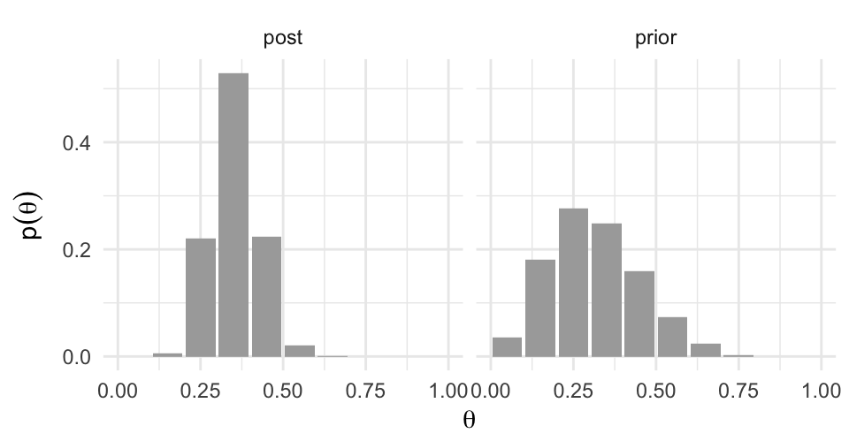

```r
# Alargamos los datos para graficar
dists_l <- dists %>%
  gather(dist, val, prior:post)

ggplot(dists_l, aes(x = theta, y = val)) +
  geom_bar(stat = "identity", fill = "darkgray") +
  facet_wrap(~ dist) +
  labs(x = expression(theta), y = expression(p(theta)))
```

¿Cómo se ve la distribución posterior si tomamos una muestra de tamaño 90 donde observamos la misma proporción de éxitos. Realiza los cálculos y graficala como un panel adicional de la gráfica anterior.

- ¿Cómo definirías la distribución inicial si no tuvieras conocimiento de los artículos y expertos?

#### Inicial continua

La proporción $\theta$ es un parámetro continuo por lo que una alternativa a la inicial discreta es definir una incial continua en el $(0,1)$, la distribución Beta es un buen candidato, como podemos ver en la siguiente gráfica, la distribución Beta puede tomar formas muy variadas:

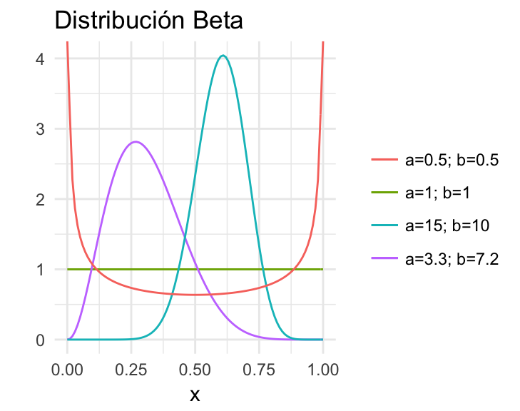

```r
base <- ggplot(data_frame(x = c(0, 1)), aes(x))
base +
    stat_function(fun = dbeta, args = list(shape1 = 1, shape2 = 1),
        aes(colour = "a=1; b=1")) +
    stat_function(fun = dbeta, args = list(shape1 = 3.26, shape2 = 7.19),
        aes(colour = "a=3.3; b=7.2")) +
    stat_function(fun = dbeta, args = list(shape1 = 15, shape2 = 10),
        aes(colour = "a=15; b=10")) +
    stat_function(fun = dbeta, args = list(shape1 = 0.5, shape2 = 0.5),
        aes(colour = "a=0.5; b=0.5")) +
    labs(y = "", title = "Distribución Beta", colour = "")
```

Esta distribución tiene dos parámetros, $\theta \sim Beta(a,b)$:
$$p(\theta) = \frac{\theta^{a-1}(1-\theta)^{b-1}}{B(a,b)}$$
donde $B(a,b)$ es una constante de normalización definida como,
$$B(a,b)=\frac{\Gamma(a)\Gamma(b)}{\Gamma(a+b)}$$
y $\Gamma(x) = \int_0^{\infty}t^{x-1}e^{-t}$, (si $x$ es un entero positivo, $\Gamma(x) = (x-1)!$).

Es difícil escoger directamente los parámetros $a,b$ que describan nuestras creencias, sin embargo, podemos derivarlos usando los percentiles, si creemos que la mediana y el percentil del $90\%$ de la distribución están dados por $0.3$ y $0.5$ respectivamente, podemos encontrar los parámetros $a,b$ que reflejen esta creencia usando la siguiente función:

```r
quantile1 <- list(p = 0.5, x = 0.3)
quantile2 <- list(p = 0.9, x = 0.5)
beta.select(quantile1, quantile2)
```

```
#> [1] 3.26 7.19
```

[figure not shown]

```r
base +
    stat_function(fun = dbeta, args = list(shape1 = 3.26, shape2 = 7.19),
        aes(color = "inicial, a=3.26;b=7.19")) + # inicial
    stat_function(fun = dbeta, args = list(shape1 = 12, shape2 = 20),
        aes(color = "verosimilitud, a=12;b=20")) + # verosimilitud
    stat_function(fun = dbeta, args = list(shape1 = 15.26, shape2 = 26.19),
        aes(color = "posterior, a=15.26;b=15.26")) +
    labs(y = "", colour = "", x = expression(theta))
```

```r
qbeta(c(0.05, 0.95), 15.26, 26.19)
```

```
#> [1] 0.250 0.494
```

¿Cómo se ve la distribución posterior cuando aumenta el tamaño de la muestra?

Resumiendo lo anterior, en estadística bayesiana (paramétrica):

- Cuantificamos la información (o incertidumbre) acerca del parámetro desconocido $\theta$ mediante distribuciones de probabilidad.
- Antes de observar datos $x$, cuantificamos la información de $\theta$ externa a $x$ en una **distribución a priori** $p(\theta)$, esto es, la distribución a priori resume nuestras creencias acerca del parámetro ajenas a los datos. Por otra parte, cuantificamos la información de $\theta$ asociada a $x$ mediante la **distribución de verosimilitud** $p(x|\theta)$.
- Combinamos la información a priori y la información que provee $x$ mediante el **teorema de Bayes** obteniendo así la **distribución posterior** $p(\theta|x) \propto p(x|\theta)p(\theta)$.
- Las inferencias se obtienen de resúmenes de la distribución posterior.

Ahora, en el teorema de Bayes también encontramos el término $p(x)$ que denominamos la **evidencia**, esta última también se conoce como verosimilitud marginal o inicial predictiva.
$$p(\theta|x)=\frac{p(x|\theta)p(\theta)}{p(x)}$$

La evidencia es la probabilidad de los datos de acuerdo al modelo y se calcula sumando a lo largo de todos los posibles valores de los parámetros y ponderando por nuestra certidumbre en esos valores de los parámetros.

Es importante notar que hablamos de valores de los parámetros $\theta$ únicamente en el contexto de un modelo particular pues este el que da sentido a los parámetros. Podemos hacer evidente el modelo en la notación,

$$p(\theta|x,M)=\frac{p(x|\theta,M)p(\theta|M)}{p(x|M)}$$

en este contexto la evidencia se define como:

$$p(x|M)=\int p(x|\theta,M)p(\theta|M)d\theta$$

La notación anterior es conveniente sobre todo cuando estamos considerando más de un modelo y queremos usar los datos para determinar la certeza que tenemos en cada modelo. Supongamos que tenemos dos modelos $M_1$ y $M_2$, entonces podemos calcular el cociente de $p(M_1|x)$ y $p(M_2|x)$ obteniendo:

$$\frac{p(M_1|x)}{p(M_2|x)} = \frac{p(x|M_1) \cdot p(M_1)}{p(x|M_2)\cdot p(M_2)}$$

El cociente de evidencia $\frac{p(x|M_1)}{p(x|M_2)}$ se conoce como **factor de Bayes**.

### Invarianza en el orden de los datos

Vimos que la regla de Bayes nos permite pasar del conocimiento inicial $p(\theta)$ al posterior $p(\theta|x)$ conforme recopilamos datos. Supongamos ahora que observamos más datos, los denotamos $x'$, podemos volver a actualizar nuestras creencias pasando de $p(\theta|x)$ a $p(\theta|x,x')$. Entonces podemos preguntarnos si nuestro conocimiento posterior cambia si actualizamos de acuerdo a $x$ primero y después $x'$ o vice-versa. La respuesta es que si $p(x|\theta)$ y $p(x'|\theta)$ son *iid* entonces el orden en que actualizamos nuestro conocimiento no afecta la distribución posterior.

La **invarianza al orden** tiene sentido intuitivamente: Si la función de verosimilitud no depende del tiempo o del ordenamineto de los datos, entonces la posterior tampoco tiene porque depender del ordenamiento de los datos.

### Objetivos de la inferencia

Los tres objetivos de la inferencia son: estimación de parámetros, predicción de valores y comparación de modelos.

1. La **estimación de parámetros** implica determinar hasta que punto creemos en cada posible valor del parámetro. La distribución posterior sobre los valores de los parámetros $\theta$ es nuestra estimación para dichos valores.

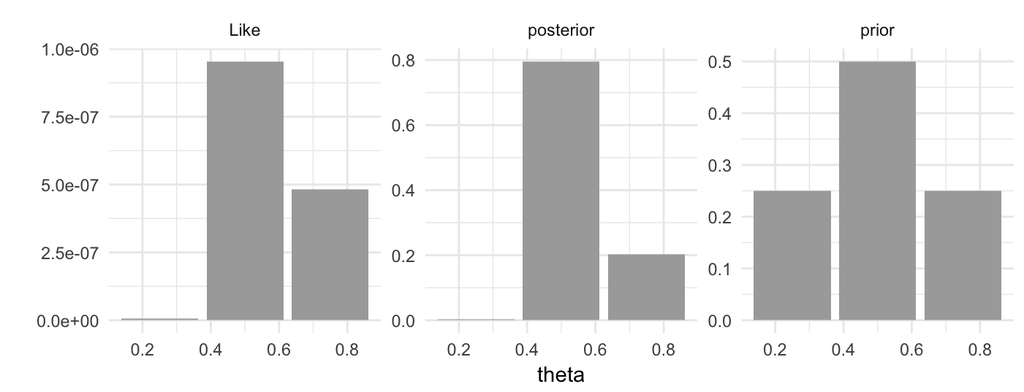

```r
# Modelo 1, 3 posibles valores
p_M1 <- data_frame(theta = c(0.25, 0.5, 0.75), prior = c(0.25, 0.5, 0.25),
  modelo ="M1")

# Modelo 2, Creamos una inicial que puede tomar más valores
p <- seq(0, 24, 1)
p2 <- c(p, 24, sort(p, decreasing = TRUE))
p_M2 <- data_frame(theta = seq(0, 1, 0.02), prior = p2 / sum(p2),
  modelo = "M2")

N <- 20 # estudiantes
z <- 12 # éxitos

dists_h <- bind_rows(p_M1, p_M2) %>% # base de datos horizontal
    group_by(modelo) %>%
    mutate(
        Like = theta ^ z * (1 - theta) ^ (N - z), # verosimilitud
        posterior = (Like * prior) / sum(Like * prior)
      )

dists <- dists_h %>% # base de datos larga
    gather(dist, valor, prior, Like, posterior)

ggplot(filter(dists, modelo == "M1"), aes(x = theta, y = valor)) +
    geom_bar(stat = "identity", fill = "darkgray") +
    facet_wrap(~ dist, scales = "free") +
    scale_x_continuous("theta", breaks = seq(0, 1, 0.2)) +
    labs(y = "")
```

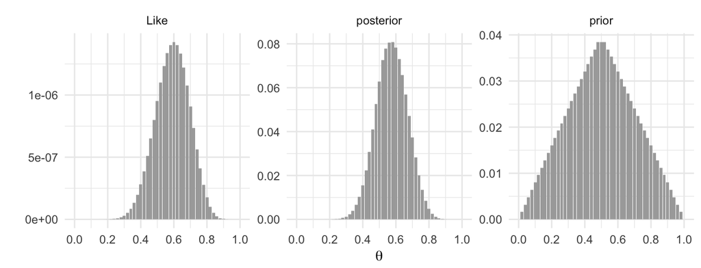

```r
ggplot(filter(dists, modelo == "M2"), aes(x = theta, y = valor)) +
    geom_bar(stat = "identity", fill = "darkgray") +
    facet_wrap(~ dist, scales = "free") +
    scale_x_continuous(expression(theta), breaks = seq(0, 1, 0.2)) +
    labs(y = "")
```

```r
# ggplot(dists, aes(x = theta, y = valor)) +
#     geom_bar(stat = "identity", fill = "darkgray") +
#     facet_wrap( ~ modelo + dist, scales = "free") +
#     scale_x_continuous(expression(theta), breaks = seq(0, 1, 0.2)) +
#     labs(y = "")
```

2. **Predicción** de valores. Usando nuestro conocimiento actual nos interesa predecir la probabilidad de datos futuros. La probabilidad predictiva de un dato $y$ (no observado) se determina promediando las probabilidades predictivas de los datos a lo largo de todos los posibles valores de los parámetros y ponderados por la creencia en los valores de los parámetros:

$$p(y) =\int p(y|\theta)p(\theta)d\theta$$

Notese que la ecuación anterior coincide con la correspondiente a la evidencia, con la diferencia de que la evidencia se refiere a un valor observado y en esta ecuación estamos calculando la probabilidad de cualquier valor $y$.

Por ejemplo podemos usar las creencias iniciales del modelo 1, que propusimos arriba para calcular la probabilidad predictiva de observar águila:

$$p(y=S) = \sum_{\theta}p(y=A|\theta)p(\theta) = 0.5$$

Vale la pena destacar que las prediciones son probabilidades de cada posible valor condicional a nuestro modelo de creencias actuales. Si nos interesa predecir un valor particular en lugar de de una distribución a lo largo de todos los posibles valores podemos usar la media de la distribución predictiva. Por tanto el valor a predecir sería:

$$p(y)=\int yp(y) dy$$

La integral anterior únicamente tiene sentido si $y$ es una variable continua. Si $y$ es nominal, como el resultado de un volado, entonces podemos usar el valor más probable.

3. **Comparación de modelos**, una caracterítica conveniente de la comparación de modelos en estadística bayesiana es que la complejidad del modelo se toma en cuenta de manera automática.

Recordemos los dos modelos discretos, en el primero supusimos que el parámetro $\theta$ únicamente puede tomar uno de 3 valores (0.25, 0.5, 0.75), esta restricción dió lugar a un modelo simple. Por su parte, el modelo 2 es más complejo y permite muchos más valores de $\theta$ (51). La forma de la distribución inicial es triangular en ambos casos y el valor de mayor probabilidad inicial es $\theta = 0.50$ y reflejamos que creemos que es menos factible que el valor se encuentre en los extremos.

Podemos calcular el factor de Bayes para distintos datos observados:

```r
factorBayes <- function(N, z){
  evidencia <- bind_rows(p_M1, p_M2) %>% # base de datos horizontal
    group_by(modelo) %>%
    mutate(
      Like = theta ^ z * (1 - theta) ^ (N - z), # verosimilitud
      posterior = (Like * prior) / sum(Like * prior)
    ) %>%
    summarise(evidencia = sum(prior * Like))
  print(evidencia)
  return(evidencia[1, 2] / evidencia[2, 2])
}

factorBayes(50, 25)
```

```
#> # A tibble: 2 x 2
#>   modelo evidencia
#>    <chr>     <dbl>
#> 1     M1  4.44e-16
#> 2     M2  2.75e-16
#>   evidencia
#> 1      1.61
```

```r
factorBayes(100, 75)
```

```
#> # A tibble: 2 x 2
#>   modelo evidencia
#>    <chr>     <dbl>
#> 1     M1  9.46e-26
#> 2     M2  4.17e-26
#>   evidencia
#> 1      2.27
```

```r
factorBayes(100, 10)
```

```
#> # A tibble: 2 x 2
#>   modelo evidencia
#>    <chr>     <dbl>
#> 1     M1  1.36e-18
#> 2     M2  2.47e-16
#>   evidencia
#> 1   0.00549
```

```r
factorBayes(40, 38)
```

```
#> # A tibble: 2 x 2
#>   modelo evidencia
#>    <chr>     <dbl>
#> 1     M1  2.79e-07
#> 2     M2  8.95e-06
#>   evidencia
#> 1    0.0312
```

La evidencia de un modelo $p(x|M)$ no dice mucho por si misma, si no que es mas relevante en el contexto del factor de Bayes (la eviencia relativa de dos modelos). Es importante recordar que la comparación de modelos nos habla únicamente de la evidencia relativa de un modelo; sin embargo, puede que ninguno de los modelos que estamos considerando sean adecuados para nuestros datos, por lo que más adelante estudiaremos maneras de evaluar un modelo.

### Calculo de la distribución posterior

En la inferencia Bayesiana se requiere calcular el denominador de la fórmula de Bayes $p(x)$, es común que esto requiera que se calcule una integral complicada; sin embargo hay algunas maneras de evitar esto,

1. El camino tradicional consiste en usar funciones de verosimilitud con dsitribuciones iniciales conjugadas. Cuando una distribución inicial es conjugada de la verosimilitud resulta en una distribución posterior con la misma forma funcional que la distribución inicial.
2. Otra alternativa es aproximar la integral numericamente. Cuando el espacio de parámetros es de dimensión chica, se puede cubrir con una cuadrícula de puntos y la integral se puede calcular sumando a través de dicha cuadrícula. Sin embargo cuando el espacio de parámetros aumenta de dimensión el número de puntos necesarios para la aproximación crece demasiado y hay que recurrir a otas técnicas.
3. Se ha desarrollado una clase de métodos de simulación para poder calcular la distribución posterior, estos se conocen como cadenas de Markov via Monte Carlo (MCMC por sus siglas en inglés). El desarrollo de los métodos MCMC es lo que ha propiciado el desarrollo de la estadística bayesiana en años recientes.

### Ejemplo: Bernoulli

#### Distribuciones conjugadas

Comenzaremos con el modelo Beta-Binomial. Recordemos que si X en un experimento con dos posibles resultados, X se distribuye Bernoulli y la función de probabilidad esta definida por:

$$p(x|\theta)=\theta^x(1-\theta)^{1-x}$$

recordemos también que podemos pensar en la fórmula anterior como una función de $x$, donde $x$ toma uno de dos valores 0 o 1. También podemos pensar que $x$ esta fija (observada) y la expresión es una función de $\theta$, en este caso, la ecuación especifica la probabilidad de un valor fijo $x$ para un valor de $\theta$ y la llamamos la verosimilitud de $\theta$. En inferencia Bayesiana la función $p(x|theta)$, usualmente se considera como función de $\theta$.

Ahora, si lanzamos una moneda $N$ veces tenemos un conjunto de datos $\{x_1,...,x_N\}$, suponemos que los lanzamientos son independientes por lo que la probabilidad de observar el conjunto de $N$ lanzamientos es el producto de las probabilidades para cada observación:

$$p(x_1,...,x_N|\theta) = \prod_{n=1}^N p(x_n|\theta)$$
$$= \theta^z(1 - \theta)^{N-z}$$

donde $z$ denota el número de éxitos (águilas).

Ahora, en principio para describir nuestras creencias iniciales podríamos usar cualquier función de densidad con soporte en $[0, 1]$, sin embargo, sería conveniente que el producto $p(x|\theta)p(\theta)$ (el numerador de la fórmula de Bayes) resulte en una función con la misma forma que $p(\theta)$. Cuando este es el caso, las creencias inicial y posterior se describen con la misma distribución. Esto es conveninte pues si obtenemos nueva información podemos actualizar nuestro conocimiento de manera inmediata, conservando la forma de las distribuciones.

Cuando las funciones $p(x|\theta)$ y $p(\theta)$ se combinan de tal manera que la distribución posterior pertenece a la misma familia (tiene la misma forma) que la distribución inicial, entonces decimos que $p(\theta)$ es **conjugada** para $p(x|\theta)$.

Vale la pena notar que la inicial es conjugada únicamente respecto a una función de verosimilitud particular.

Una distribución conjugada para $p(x|\theta) = \theta^S(1 - \theta)^{M-S}$ es una Beta(a, b)
$$p(\theta) = \frac {\theta^{a-1}(1-\theta)^{b-1}}{B(a,b)}$$

Para describir nuestro conocimiento inicial podemos explorar la media y desviación estándar de la distribución beta, la media es
$$\bar{\theta} = a/(a+b)$$
por lo que si $a=b$ la media es 0.5 y conforme aumenta $a$ en relación a $b$ aumenta la media. La desviación estándar es

$$\sqrt{\bar{\theta}(1-\bar{\theta})/(a+b+1)}$$

Una manera de seleccionar los parámetros $a$ y $b$ es pensar en la proporción media de águilas (m) y el tamaño de muestra (n). Ahora, $m=a/(a+b)$ y $n = a+b$, obteniendo.

$$a=mn, b=(1-m)n$$

Otra manera es comenzar con la media y la desviación estándar. Al usar este enfoque debemos recordar que la desviación estándar debe tener sentido en el contexto de la densidad beta. En particular la desviación estándar típicamente es menor a 0.289 que corresponde a la desviación estándar de una uniforme. Entonces, para una densidad beta con media $m$ y desviación estándar $s$, los parámetros son:
$$a=m\bigg(\frac{m(1-m)}{s^2}- 1\bigg), b=(1-m)\bigg(\frac{m(1-m)}{s^2}- 1\bigg)$$

Una vez que hemos determinado una inicial conveniente para la verosimilitud Bernoulli, veamos la posterior. Supongamos que observamos $N$ lanzamientos de los cuales $z$ son águilas, entonces podemos ver que la posterior es nuevamente una densidad Beta.

$$p(\theta|z)\propto \theta^{a+z-1}(1 -\theta)^{(N-z+b)-1}$$

Concluímos entonces que si la distribución inicial es Beta(a,b), la posterior es Beta(z+a,N-z+b).

Vale la pena explorar la relación entre la distribución inicial y posterior en las medias. La media incial es
$$a/(a+b)$$
y la media posterior es
$$(z+a)/[(z+a) + (N-z+b)]=(z+a)/(N+a+b)$$
podemos hacer algunas manipulaciones algebráicas para escribirla como:

$$\frac{z+a}{N+a+b}=\frac{z}{N}\frac{N}{N+a+b} + \frac{a}{a+b}\frac{a+b}{N+a+b}$$

es decir, podemos escribir la media posterior como un promedio ponderado entre la media inicial $a/(a+b)$ y la proporción observada $z/N$.

Ahora podemos pasar a la inferencia, comencemos con estimación de la proporción $\theta$. La distribución posterior resume todo nuestro conocimiento del parámetro $\theta$, en este caso podemos graficar la deistribución y extraer valores numéricos como la media.

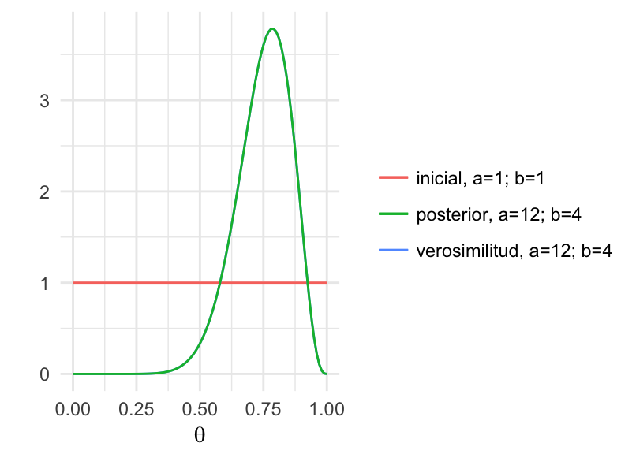

```r
# N = 14, z = 11, a = 1, b = 1
base +
    stat_function(fun = dbeta, args = list(shape1 = 1, shape2 = 1),
        aes(colour = "inicial, a=1; b=1")) +
    stat_function(fun = dbeta, args = list(shape1 = 12, shape2 = 4),
        aes(colour = "verosimilitud, a=12; b=4")) +
    stat_function(fun = dbeta, args = list(shape1 = 12, shape2 = 4),
        aes(colour = "posterior, a=12; b=4")) +
      labs(y = "", colour = "", x = expression(theta))
```

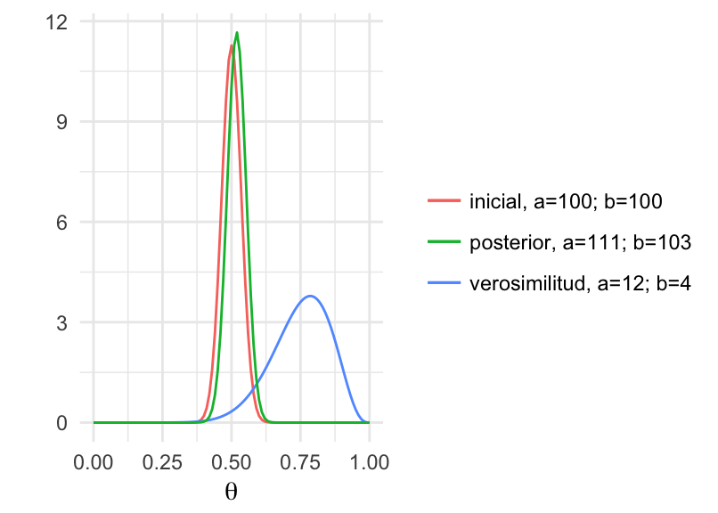

```r
# N = 14, z = 11, a = 100, b = 100
base +
    stat_function(fun = dbeta, args = list(shape1 = 100, shape2 = 100),
        aes(colour = "inicial, a=100; b=100")) +
    stat_function(fun = dbeta, args = list(shape1 = 12, shape2 = 4),
        aes(colour = "verosimilitud, a=12; b=4")) +
    stat_function(fun = dbeta, args = list(shape1 = 111, shape2 = 103),
        aes(colour = "posterior, a=111; b=103")) +
      labs(y = "", colour = "", x = expression(theta))
```

Una manera de resumir la distribución posterior es a través de intervalos de probabilidad, otro uso de los intervalos es establecer que valores del parámetro son creíbles.

Calcula un intervalo del 95% de probabilidad para cada una de las distribuciones posteriores del ejemplo.

Ahora pasemos a predicción, calculamos la probabilidad de $y =1$:

$$p(y = 1) = \int p(y=1|\theta)p(\theta|z)d\theta$$
$$=\int \theta p(\theta|z,N) d\theta$$
$$=(z+a)/(N+a+b)$$
Esto es, la probabilidad predictiva de águila es la media de la distribución posterior sobre $\theta$.

Finalmente, comparemos modelos. Para esto calculamos la evidencia $p(x|M)$ para cada modelo:

$$p(x|M)=\int p(x|\theta,M)p(\theta|M)d\theta$$

en este caso los datos están dados por $z$ y N, en el caso de la incial beta es fácil calcular la evidencia:

$$p(z)=B(z+a,N-z+b)/B(a,b)$$

En nuestro ejemplo, una inicial tuiene un pico en 0.5 mientras que la otra es uniforme. Por otra parte, la proporción de 1 observados en la muestra no es cercana a 0.5 por lo que la inicial picuda no captura los datos muy bien.

```r
# N = 14, z = 11, a = 1, b = 1
beta(12, 4) / beta(1, 1)
```

```
#> [1] 0.000183
```

```r
# N = 14, z = 12, a = 100, b = 100
beta(126, 126) / beta(100, 100)
```

```
#> [1] 1.98e-16
```

Supongamos que observamos una secuencia en la que la mitad de los volados resultan en águila:

```r
# N = 14, z = 7, a = 1, b = 1
beta(8, 8) / beta(1, 1)
```

```
#> [1] 1.94e-05
```

```r
# N = 14, z = 7, a = 100, b = 100
beta(107, 107) / beta(100, 100)
```

```
#> [1] 5.9e-05
```

En general, preferimos un modelo con un valor mayor de $p(x|\theta)$ pero la preferencia no es absoluta, una diferencia chica no nos dice mucho. Debemos considerar que los datos no son mas que una muestra aleatoria.

#### Aproximación por cuadrícula

Supongamos que la distribución beta no describe nuestras creencias de manera adecuada. Por ejemplo, mis creencias podrían estar mejor representadas por una distribución trimodal: la moneda esta fuertemente sesgada hacia sol, fuertemente sesgada hacia águila o es justa. No hay parámetros en una beta que puedan describir este patrón.

Exploraremos entonces una técnica de aproximación numérica de la distribución posterior que consiste en definir la distribución inicial en una cuadrícula de valores de $\theta$. En este método no necesitamos describir nuestras creencias mediante una función matemática ni realizar integración analítica. Suponemos que existe únicamente un número finito de valores de $\theta$ que creemos que pueden ocurrir (el primer ejemplo que estudiamos usamos esta técnica). Es así que la regla de Bayes se escribe como:

$$p(x|\theta)=\frac{p(x|\theta)p(\theta)}{\sum_{\theta}p(x|\theta)p(\theta)}$$

Entonces, si podemos discretizar una distribución inicial continua mediante una cuadrícula de masas de probabilidad discreta podemos usar la versión discreta de la regla de Bayes. El proceso consiste en dividir el dominio en regiones, crear un rectángulo con la altura correspondiente al valor de la densidad en el punto medio. Aproximamos el área de cada región mediante la altura del rectángulo.

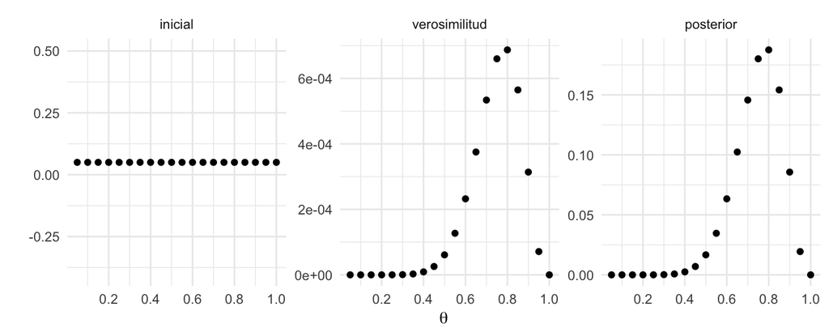

```r
# N = 14, z = 11, a = 1, b = 1
N = 14; z = 11
inicial <- data.frame(theta = seq(0.05, 1, 0.05), inicial = rep(1/20, 20))
dists_h <- inicial %>%
    mutate(
        verosimilitud = theta ^ z * (1 - theta) ^ (N - z), # verosimilitud
        posterior = (verosimilitud * inicial) / sum(verosimilitud * inicial)
        )
dists <- dists_h %>% # base de datos larga
    gather(dist, valor, inicial, verosimilitud, posterior) %>%
    mutate(dist = factor(dist, levels = c("inicial", "verosimilitud", "posterior")))

ggplot(dists, aes(x = theta, y = valor)) +
    geom_point() +
    facet_wrap(~ dist, scales = "free") +
    scale_x_continuous(expression(theta), breaks = seq(0, 1, 0.2)) +
    labs(y = "")
```

y lo podemos comparar con la versión continua (distribución beta).

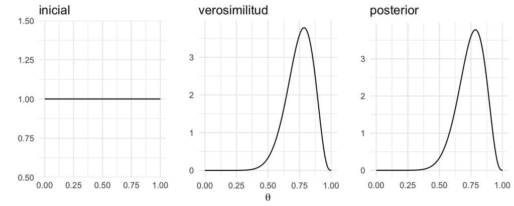

En cuanto a la estimación, la tabla de probabilidades nos da una estimación para los valores de los parámetros. Podemos calcular la media de $\theta$ como el promedio ponderado por las probabilidades:

$\bar{\theta}=\sum_{\theta} \theta p(\theta|x)$

```r
head(dists_h)
```

```
#>   theta inicial verosimilitud posterior
#> 1  0.05    0.05      4.19e-15  1.14e-12
#> 2  0.10    0.05      7.29e-12  1.99e-09
#> 3  0.15    0.05      5.31e-10  1.45e-07
#> 4  0.20    0.05      1.05e-08  2.86e-06
#> 5  0.25    0.05      1.01e-07  2.75e-05
#> 6  0.30    0.05      6.08e-07  1.66e-04
```

```r
sum(dists_h$posterior * dists_h$theta)
```

```
#> [1] 0.75
```

En cuanto a los intervalos de probabilidad, debido a que estamos usando masas discretas, la suma de las masas en un intervalo usualmente no será igual a 95% y por tanto elegimos los puntos tales que la masa sea mayor a igual a 95% y la masa total sea lo menor posible, en nuestro ejemplo podemos usar cuantiles.

```r
dist_cum <- cumsum(dists_h$posterior) #vector de distribución acumulada
lb <- which.min(dist_cum < 0.05) - 1
ub <- which.min(dist_cum < 0.975)
dists_h$theta[lb]
```

```
#> [1] 0.5
```

```r
dists_h$theta[ub]
```

```
#> [1] 0.9
```

Para el problema de predicción, la probabilidad predictiva para el siguiente valor $y$ es simplemente la probabilidad de que ocurra dicho valor ponderado por la probabilidad posterior correspondiente:

$$p(y|x)=\int p(y|\theta)p(\theta|x)d\theta$$
$$\approx \sum_{\theta} p(y|\theta)p(\theta|x)$$

Calcula la probabilidad predictiva para $y=1$ usando los datos del ejemplo.

Finalmente, para la comparación de modelos la integral que define la evidencia

$$p(x|M)=\int p(x|\theta,M)p(\theta|M)d\theta$$

se convierte en una suma

$$p(x|M)\approx \sum_{\theta} p(x|\theta,M)p(\theta|M)d\theta$$

```r
# calcula el factor de Bayes para el experimento Bernoulli Modelos M1 y M2
factorBayes <- function(M, s){
  evidencia <- rbind(p_M1, p_M2) %>% # base de datos horizontal
    group_by(modelo) %>%
    mutate(
      Like = theta ^ s * (1 - theta) ^ (M - s), # verosimilitud
      posterior = (Like * prior) / sum(Like * prior)
    ) %>%
    summarise(evidencia = sum(prior * Like))
  print(evidencia)
  return(evidencia[1, 2] / evidencia[2, 2])
}

factorBayes(50, 25)
```

```
#> # A tibble: 2 x 2
#>   modelo evidencia
#>    <chr>     <dbl>
#> 1     M1  4.44e-16
#> 2     M2  2.75e-16
#>   evidencia
#> 1      1.61
```

#### Metrópolis

Hay ocasiones en las que los métodos de inicial conjugada y aproximación por cuadrícula no funcionan, hay casos en los que la distribución beta no describe nuestras creencias iniciales. Por su parte, la aproximación por cuadrícula no es factible cuando tenemos varios parámetros. Es por ello que surge la necesidad de utilizar métodos de Monte Carlo vía Cadenas de Markov (MCMC).

En Metropolis se asume que podemos calcular $p(\theta)$ para un valor particular de $\theta$ y el valor de la verosimilitud $p(x|\theta)$ para cualquier $x$, $\theta$ dados. En realidad, el método únicamente requiere que se pueda calcular el producto de la inicial y la verosimilitud, y sólo hasta una constante de proporcionalidad. Lo que el método produce es una aproximación de la distribución posterior $p(\theta|x)$ mediante una muestra de valores $\theta$ obtenido de dicha distribución.

**Caminata aleatoria**. Con el fin de entender el algoritmo comenzaremos estudiando el concepto de caminata aleatoria. Supongamos que un vendedor de enciclopedias trabaja a lo largo de una cadena de islas. Constantemente viaja entre las islas ofreciendo sus productos. Al final de un día de trabajo decide si permanece en la misma isla o se transporta a una de las 2 islas vecinas. El vendedor ignora la distribución de la población en las islas; sin embargo, una vez que se encuentra en una isla puede investigar la población de la misma y también de la isla a la que se propone viajar después. El objetivo del vendedor es visitar las islas de manera proporcional a la población de cada una. Con esto en mente el vendedor utiliza el siguiente proceso: 1) Lanza un volado, si el resultado es águila se propone ir a la isla del lado izquierdo de su ubicación actual y si es sol a la del lado derecho. 2) Si la isla propuesta en el paso anterior tiene población mayor a la población de la isla actual, el vendedor decide viajar a ella. Si la isla vecina tiene población menor, entonces visita la isla propuesta con una probabilidad que depende de la población de las islas. Sea $P_{prop}$ la población de la isla propuesta y $P_{actual}$ la población de la isla actual. Entonces el vendedor cambia de isla con probabilidad $p_{mover}=P_{prop}/P_{actual}$.

A la larga, si el vendedor sigue la heurística anterior la probabilidad de que el vendedor este en alguna de las islas coincide con la población relativa de la isla.

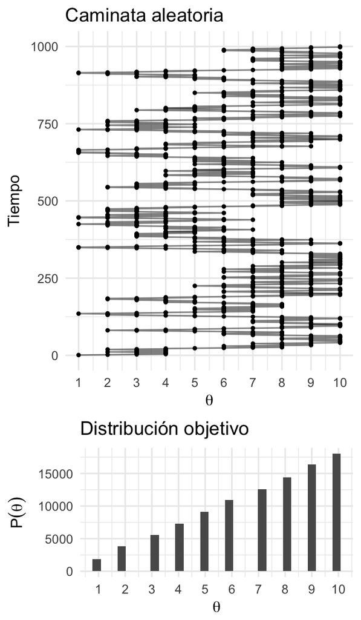

```r
islas <- data.frame(islas = 1:10, pob = 1:10)

caminaIsla <- function(i){ # i: isla actual
  u <- runif(1) # volado
  v <- ifelse(u < 0.5, i - 1, i + 1)  # isla vecina (índice)
  if(v < 1 | v > 10){ # si estas en los extremos y el volado indica salir
    return(i)
  }
  u2 <- runif(1)
  p_move = min(islas$pob[v] / islas$pob[i], 1)
  if(p_move  > u2){
    return(v) # isla destino
  }
  else{
    return(i) # me quedo en la misma isla
  }
}

pasos <- 100000
camino <- numeric(pasos)
camino[1] <- sample(1:10, 1) # isla inicial
for(j in 2:pasos){
  camino[j] <- caminaIsla(camino[j - 1])
}

caminata <- data.frame(pasos = 1:pasos, isla = camino)

plot_caminata <- ggplot(caminata[1: 1000, ], aes(x = pasos, y = isla)) +
  geom_point(size = 0.8) +
  geom_path(alpha = 0.5) +
  coord_flip() +
  labs(title = "Caminata aleatoria") +
  scale_y_continuous(expression(theta), breaks = 1:10) +
  scale_x_continuous("Tiempo")

plot_dist <- ggplot(caminata, aes(x = isla)) +
  geom_histogram() +
  scale_x_continuous(expression(theta), breaks = 1:10) +
  labs(title = "Distribución objetivo",
       y = expression(P(theta)))

grid.arrange(plot_caminata, plot_dist, ncol = 1, heights = c(4, 2))
```

Para aproximar la distribución objetivo debemos permitir que el vendedor recorra las islas durante una sucesión larga de pasos y registramos sus visitas. Nuestra aproximación de la distribución es justamente el registro de sus visitas. Más aún, debemos tener cuidado y excluir la porción de las visitas que se encuentran bajo la influencia de la posición inicial. Esto es, debemos excluir el periodo de calentamiento. Una vez que tenemos un registro *largo* de los viajes del vendedor (excluyendo el calentamiento) podemos aproximar la distribución objetivo de cada valor de $\theta$ simplemente contando el número relativo de veces que el vendedor visitó dicha isla.

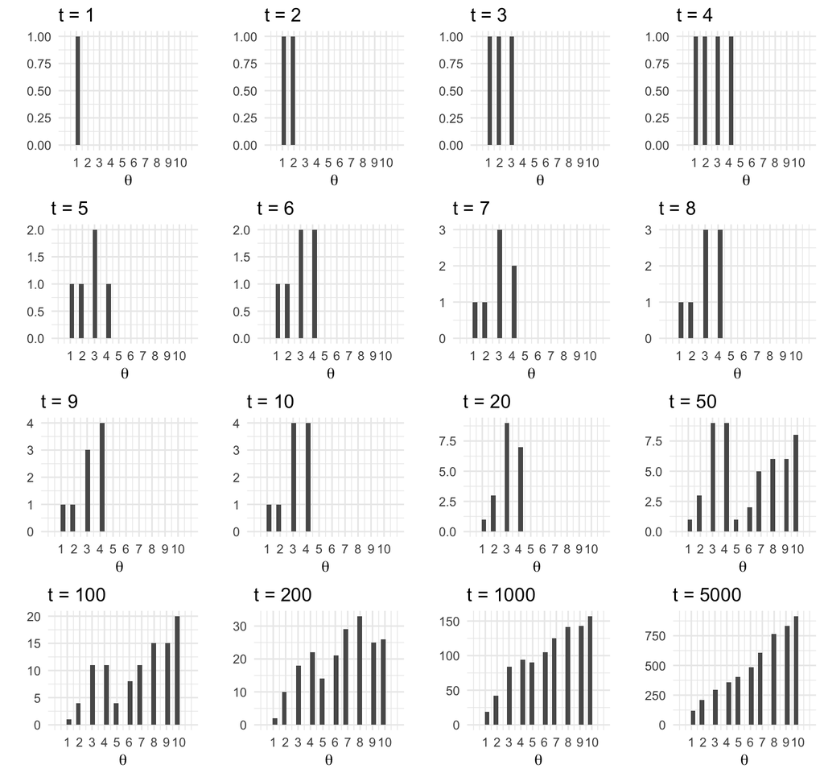

```r
t <- c(1:10, 20, 50, 100, 200, 1000, 5000)

plots_list <- lapply(t, function(i){
  ggplot(caminata[1:i, ], aes(x = isla)) +
    geom_histogram() +
    labs(y = "", x = "", title = paste("t = ", i, sep = "")) +
    scale_x_continuous(expression(theta), breaks = 1:10, limits = c(0, 11))
})

args.list <- c(plots_list,list(nrow=4,ncol=4))
do.call(grid.arrange, args.list)
```

Escribamos el algoritmo, para esto indexamos las islas por el valor $\theta$, es así que la isla del extremo oeste corresponde a $\theta=1$ y la población relativa de cada isla es $P(\theta)$:

1. El vendedor de ubica en $\theta_{actual}$ y propone moverse a la izquierda o derecha con probabilidad 0.5.

El rango de los posibles valores para moverse, y la probabilidad de proponer cada uno se conoce como **distribución propuesta**, en nuestro ejemplo sólo toma dos valores cada uno con probabilidad 0.5.

2. Una vez que se propone un movimiento, decidimos si aceptarlo. La decisión de aceptar se basa en el valor de la distribución **objetivo** en la posición propuesta, relativo al valor de la distribución objetivo en la posición actual:

$$p_{mover}=min\bigg( \frac{P(\theta_{propuesta})}{P(\theta_{actual})},1\bigg)$$

Notemos que la distribución objetivo $P(\theta)$ no necesita estar normalizada, esto es porque lo que nos interesa es el cociente $P(\theta_{propuesta})/P(\theta_{actual})$.

3. Una vez que propusimos un movimiento y calculamos la probabilidad de aceptar el movimiento aceptamos o rechazamos el movimiento generando un valor de una distribución uniforme, si dicho valor es menor a $p_{mover}$ entonces hacemos el movimiento.

Entonces, para utilizar el algoritmo necesitamos ser capaces de:

- Generar un valor de la distribución propuesta (para crear $\theta_{propuesta}$).
- Evaluar la distribución objetivo en cualquier valor propuesto (para calcular $P(\theta_{propuesta})/P(\theta_{actual})$).
- Generar un valor uniforme (para movernos con probabilidad $p_{mover}$)

Las 3 puntos anteriores nos permiten generar muestras aleatorias de la distribución objetivo, sin importar si esta está normalizada. Esta técnica es particularmente útil cuando cuando la distribución objetivo es una posterior proporcional a $p(x|\theta)p(\theta)$.

Para entender porque funciona el algoritmo de Metrópolis hace falta entender 2 puntos, primero que la distribución objetivo es **estable**: si la probabilidad *actual* de ubicarse en una posición coincide con la probabilidad en la distribución objetivo, entonces el algoritmo preserva las probabilidades.

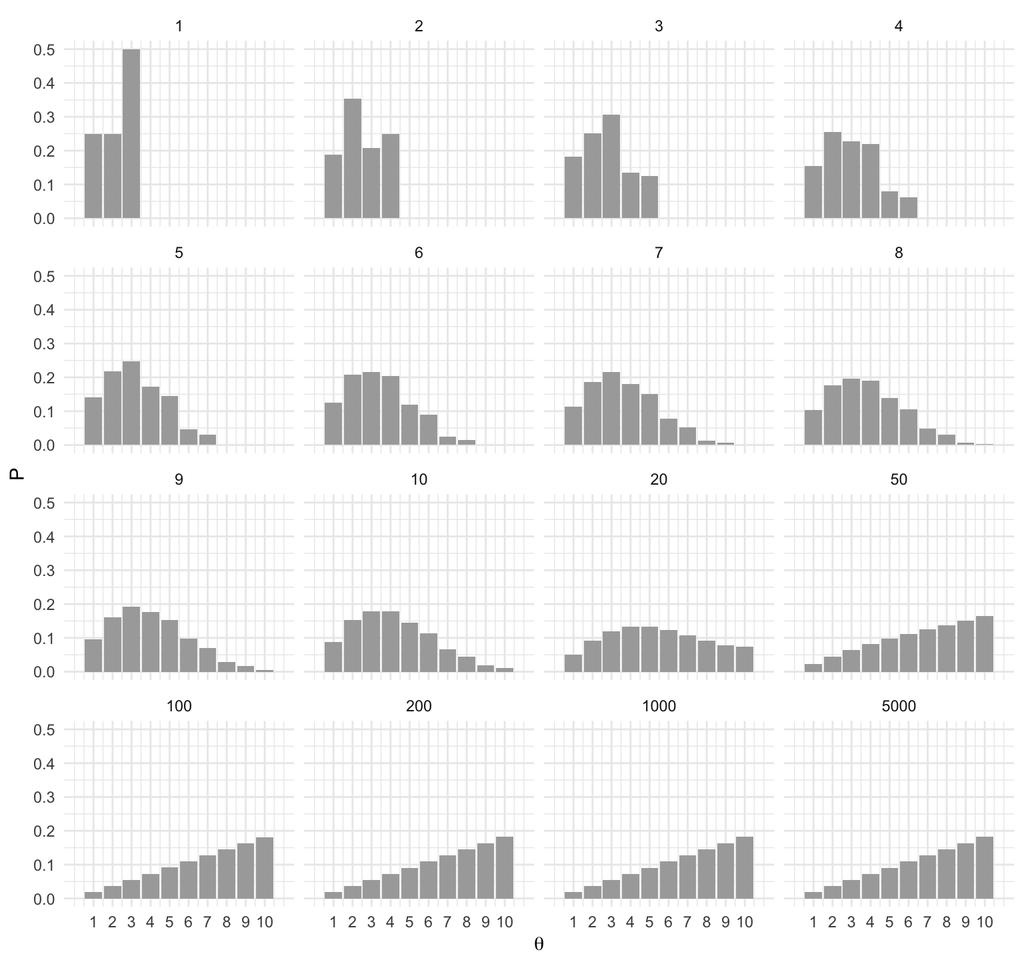

```r
library(expm)

transMat <- function(P){ # recibe vector de probabilidades (o población)
  T <- matrix(0, 10, 10)
  n <- length(P - 1) # número de estados
  for(j in 2:n - 1){ # llenamos por fila
    T[j, j - 1] <- 0.5 * min(P[j - 1] / P[j], 1)
    T[j, j] <- 0.5 * (1 - min(P[j - 1] / P[j], 1)) +
               0.5 * (1 - min(P[j + 1] / P[j], 1))
    T[j, j + 1] <- 0.5 * min(P[j + 1] / P[j], 1)
  }
  # faltan los casos j = 1 y j = n
  T[1, 1] <- 0.5 + 0.5 * (1 - min(P[2] / P[1], 1))
  T[1, 2] <- 0.5 * min(P[2] / P[1], 1)
  T[n, n] <- 0.5 + 0.5 * (1 - min(P[n - 1] / P[n], 1))
  T[n, n - 1] <- 0.5 * min(P[n - 1] / P[n], 1)
  T
}

T <- transMat(islas$pob)

w <- c(0, 1, rep(0, 8))

t <- c(1:10, 20, 50, 100, 200, 1000, 5000)
expT <- map_df(t, ~data.frame(t = ., w %*% (T %^% .)))
expT_long <- expT %>%
    gather(theta, P, -t) %>%
    mutate(theta = parse_number(theta))

ggplot(expT_long, aes(x = theta, y = P)) +
  geom_bar(stat = "identity", fill = "darkgray") +
  facet_wrap(~ t) +
  scale_x_continuous(expression(theta), breaks = 1:10, limits = c(0, 11))
```

El segundo punto es que el proceso converge a la distribución objetivo. Podemos ver, (en nuestro ejemplo sencillo) que sin importar el punto de inicio se alcanza la distribución objetivo.

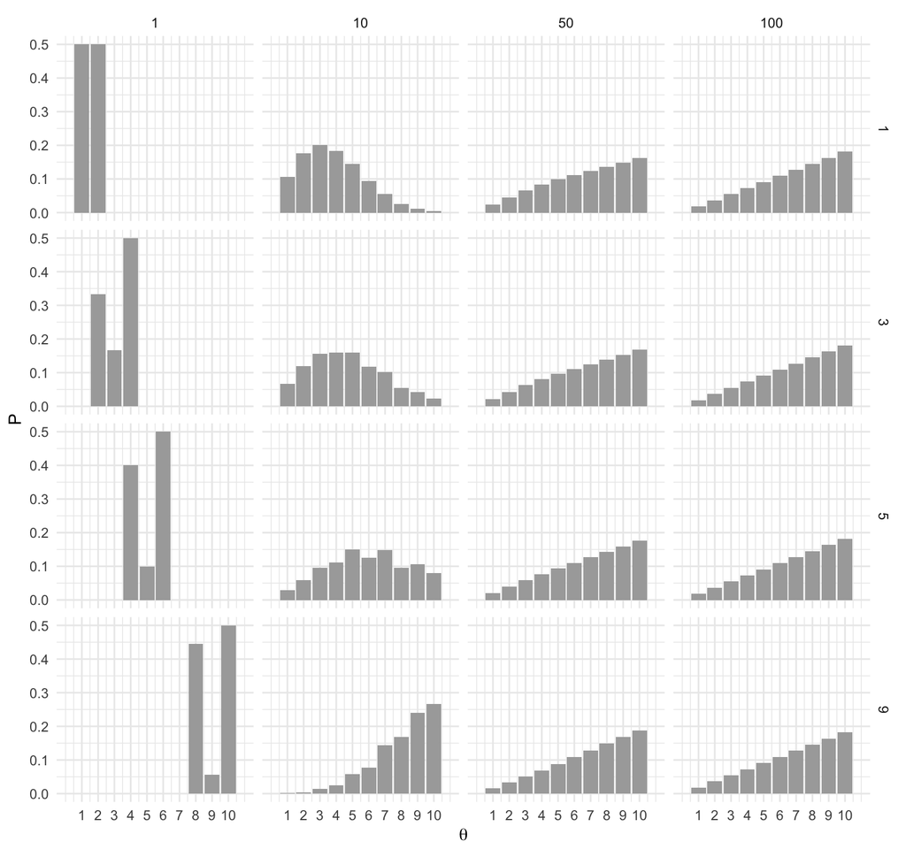

```r
inicioP <- function(i){
  w <- rep(0, 10)
  w[i] <- 1
  t <- c(1, 10, 50, 100)
  expT <- map_df(t, ~data.frame(t = ., inicio = i, w %*% (T %^% .))) %>%
    gather(theta, P, -t, -inicio) %>%
    mutate(theta = parse_number(theta))
  expT
}

expT <- map_df(c(1, 3, 5, 9), inicioP)
ggplot(expT, aes(x = as.numeric(theta), y = P)) +
  geom_bar(stat = "identity", fill = "darkgray") +
  facet_grid(inicio ~ t) +
  scale_x_continuous(expression(theta), breaks = 1:10, limits = c(0, 11))
```

#### Caso general

En la sección anterior implementamos el algoritmo de Metrópolis en un caso sencillo: las posiciones eran discretas, en una dimensión y la propuesta era únicamente mover a la izquierda o a la derecha. El algoritmo general aplica para valores continuos, en cualquier número de dimensiones y con distribuciones propuesta más generales. Lo esencial del método no cambia para el caso general, esto es:

1. Tenemos una distribución objetivo $p(\theta)$ de la cual buscamos generar muestras. Debemos ser capaces de calcular el valor de $p(\theta)$ para cualquier valor candidato $\theta$. La distribución objetivo $p(\theta)$ no tiene que estar normalizada, típicamente $p(\theta)$ es la distribución posterior de $\theta$ no normalizada, es decir, es el producto de la verosimilitud y la inicial.
2. La muestra de la distribución objetivo se genera mediante una caminata aleatoria a través del espacio de parámetros. La caminata inicia en un lugar arbitrario (definido por el usuario). El punto inicial debe ser tal que $p(\theta)>0$. La caminata avanza en cada tiempo proponiendo un movimiento a una nueva posición y después decidiendo si se acepta o no el valor propuesto. Las distribuciones propuesta pueden tener muchas formas, el objetivo es que la distribución propuesta explore el espacio de parámetros de manera eficiente.
3. Una vez que tenemos un valor propuesto decidimos si aceptar calculando:

$$p_{mover}=min\bigg( \frac{P(\theta_{propuesta})}{P(\theta_{actual})},1\bigg)$$

Y al final obtenemos valores representativos de la distribución objetivo $\{\theta_1,...,\theta_n\}$

Es importante recordar que debemos excluir las primeras observaciones pues estas siguen bajo la influencia del valor inicial.

Retomemos el problema de inferencia Bayesiana y veamos como usar el algoritmo de Metrópolis cuando la distribución objetivo es la distribución posterior.

#### Ejemplo: Bernoulli

Retomemos el ejemplo del experimento Bernoulli, iniciamos con una función de distribución que describa nuestro conocimiento inicial y tal que podamos calcular $p(\theta)$ con facilidad. En este caso elegimos una densidad beta y podemos usar función dbeta de R:

```r
# p(theta) con theta = 0.4, a = 2, b = 2
dbeta(0.4, 2, 2)
```

```
#> [1] 1.44
```

```r
# Definimos la distribución inicial
prior <- function(a = 1, b = 1){
  function(theta) dbeta(theta, a, b)
}
```

y en R:

```r
# Verosimilitid binomial
likeBern <- function(z, N){
  function(theta){
    theta ^ z * (1 - theta) ^ (N - z)
  }
}
```

Por tanto la distribución posterior $p(\theta|x)$ es, por la regla de Bayes, proporcional a $p(x|\theta)p(\theta)$. Usamos este producto como la distribución objetivo en el algoritmo de Metrópolis.

```r
# posterior no normalizada
postRelProb <- function(theta){
  mi_like(theta) * mi_prior(theta)
}
```

Implementemos el algoritmo con una inicial Beta(1,1) (uniforme) y observaciones $z = \sum{x_i}=11$ y $N = 14$, es decir lanzamos 14 volados de los cuales 11 resultan en águila.

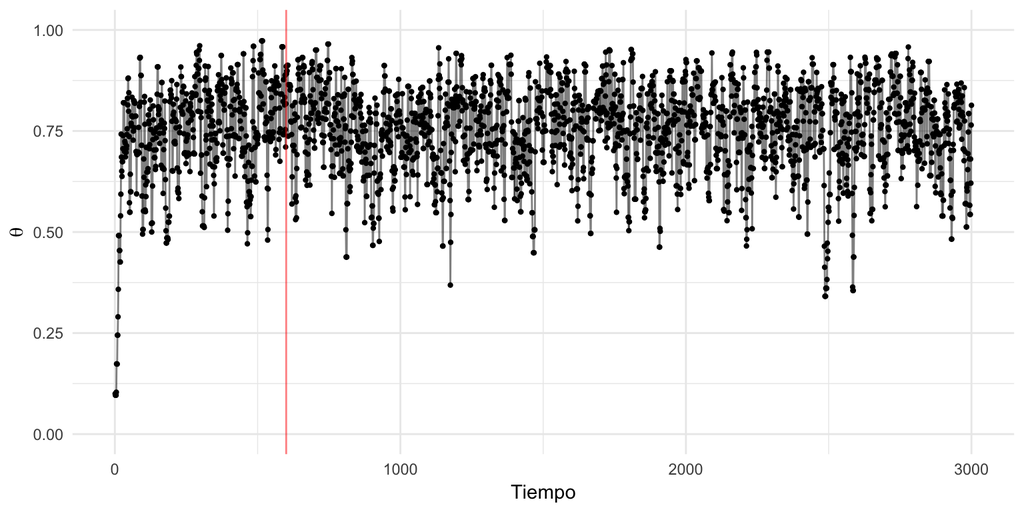

```r
# Datos observados
N = 14
z = 11

# Defino mi inicial y la verosimilitud
mi_prior <- prior() # inicial uniforme
mi_like <- likeBern(z, N) # verosimilitud de los datos observados

# para cada paso decidimos el movimiento de acuerdo a la siguiente función
caminaAleat <- function(theta){ # theta: valor actual
  salto_prop <- rnorm(1, 0, sd = 0.1) # salto propuesto
  theta_prop <- theta + salto_prop # theta propuesta
  if(theta_prop < 0 | theta_prop > 1){ # si el salto implica salir del dominio
    return(theta)
  }
  u <- runif(1)
  p_move = min(postRelProb(theta_prop) / postRelProb(theta), 1) # prob mover
  if(p_move  > u){
    return(theta_prop) # aceptar valor propuesto
  }
  else{
    return(theta) # rechazar
  }
}

set.seed(47405)

pasos <- 6000
camino <- numeric(pasos) # vector que guardará las simulaciones
camino[1] <- 0.1 # valor inicial

# Generamos la caminata aleatoria
for (j in 2:pasos){
  camino[j] <- caminaAleat(camino[j - 1])
}

caminata <- data.frame(pasos = 1:pasos, theta = camino)

ggplot(caminata[1:3000, ], aes(x = pasos, y = theta)) +
  geom_point(size = 0.8) +
  geom_path(alpha = 0.5) +
  scale_y_continuous(expression(theta), limits = c(0, 1)) +
  scale_x_continuous("Tiempo") +
  geom_vline(xintercept = 600, color = "red", alpha = 0.5)
```

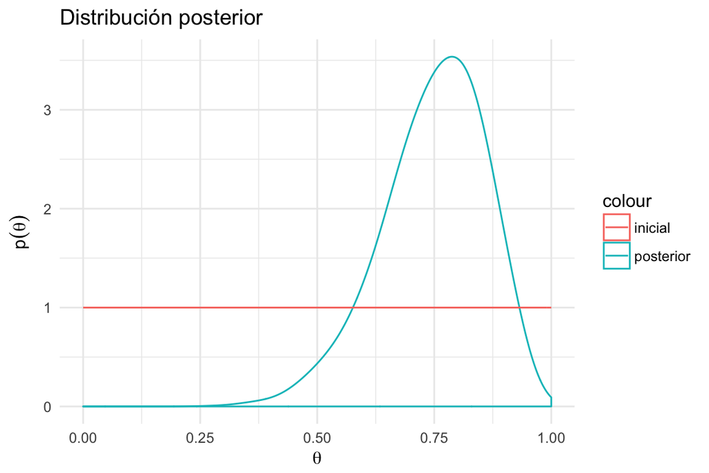

```r
# excluímos las primeras observaciones (etapa de calentamiento)
caminata_f <- filter(caminata, pasos > 600)
ggplot(caminata_f, aes(x = theta)) +
  geom_density(adjust = 2, aes(color = "posterior")) +
  labs(title = "Distribución posterior",
       y = expression(p(theta)),
       x = expression(theta)) +
  stat_function(fun = mi_prior, aes(color = "inicial")) + # inicial
  xlim(0, 1)
```

Si la distribución objetivo es muy dispersa y la distribución propuesta muy estrecha, entonces se necesitarán muchos pasos para que la caminata aleatoria cubra la distribución con una muestra representativa.

Por otra parte, si la distribución propuesta es muy dispersa podemos caer en rechazar demasiados valores propuestos. Imaginemos que $\theta_{actual}$ se ubica en una zona de densidad alta, entonces cuando los valores propuestos están lejos del valor actual se ubicarán en zonas de menor densidad y $p(\theta_{propuesta})/p(\theta_{actual})$ tenderá a ser chico y el movimiento propuesto será aceptado en pocas ocasiones.

De la muestra de valores de $p(\theta|x)$ obtenidos usando el algoritmo de Metrópolis podemos estimar aspectos de la verdadera distribución $p(\theta|x)$. Por ejemplo, para resumir la tendencia central es fácil calcular la media y la mediana.

```r
mean(caminata_f$theta)
```

```
#> [1] 0.748
```

```r
sd(caminata_f$theta)
```

```
#> [1] 0.109
```

En el caso de predicción:

```r
sims_y <- rbinom(nrow(caminata_f), size = 1, prob = caminata_f$theta)
mean(sims_y) # p(y = 1 | x) probabilidad predictiva
```

```
#> [1] 0.75
```